# GOV321

Day 0: Introduction to R

### Introduction to R

This document summarizes code that are essential to using R for data analysis. The code will center on basic operations, data parsing, and data management. Much of the code here is from the book, Data Analysis for Social Science by Elena Llaudet and Kosuke Imai Chapter 1 and Chapter 3.

Before running any of the script in this file please download R, R Studio, and the data folder used for this script. The data is ‘DSS’ folder. Make sure to also place this Rmd file within the DSS folder.

Book: [Data Analysis for Social Science: A Friendly and Practical Introduction](https://press.princeton.edu/books/hardcover/9780691199429/data-analysis-for-social-science?srsltid=AfmBOoqLPGlaKX_wXCl7hVGphtWi5FpiGvUIBj2_nqAZHIY8c02XHFUp) by Elena Llaudet and Kosuke Imai

Download R and R studio here https://posit.co/download/rstudio-desktop/  
Download DSS folder from https://press.princeton.edu/student-resources/data-analysis-for-social-science

While running the script use use `?function_name` for more information on how to use the parameters of the function (ex: `?subset`)

#### Setting the Working Directory

In R studio go to Session > Set Working Directory > Choose Directory  
MAC OS: setwd(“~/FolderName/FolderName/FolderName/DSS”)

##### Dataframe and data types

```r
a <- c(1,2,3,4)
b <- factor(c('male','female','male','male')) # factor
c<-c(19, NA, 27, 34) # numeric
d <- c("blue", "white", "black", NA) # character
e <- c(TRUE,TRUE,TRUE,FALSE) # logical

df <- data.frame(a,b,c,d,e) # create dataframe
names(df) <- c("ID","Gender", "Age","Color","Passed") # variable names
```

Often times you need to check the data types of each column before conducting any data manipulation or analysis. In these cases use `str()`.

```r
str(df)    # structure of an object
```

```
## 'data.frame':    4 obs. of  5 variables:
##  $ ID    : num  1 2 3 4
##  $ Gender: Factor w/ 2 levels "female","male": 2 1 2 2
##  $ Age   : num  19 NA 27 34
##  $ Color : chr  "blue" "white" "black" NA
##  $ Passed: logi  TRUE TRUE TRUE FALSE
```

Data types are important because some functions do not work on certain data types. For instance, a lot of functions used for calculations like `mean()` or `sum()` do not work if the data type is not numeric or logical.

```r
mean(df$Gender) # factor
```

```
## [1] NA
```

```r
mean(df$Color) # character
```

```
## [1] NA
```

```r
mean(df$Passed) # logical
```

```
## [1] 0.75
```

Some functions do not work when there are `NA` - missing data; in these cases you need specify that you want to omit `NA` using option `na.rm=TRUE`. The `Age` column in the data frame included `NA`:

```r
df$Age
```

```
## [1] 19 NA 27 34
```

```r
mean(df$Age)
```

```
## [1] NA
```

```r
max(df$Age)
```

```
## [1] NA
```

```r
min(df$Age)
```

```
## [1] NA
```

```r
mean(df$Age, na.rm=TRUE)
```

```
## [1] 26.66667
```

```r
max(df$Age, na.rm=TRUE)
```

```
## [1] 34
```

```r
min(df$Age, na.rm=TRUE)
```

```
## [1] 19
```

##### Check rows and columns

```r
dim(df) # number of rows and columns
```

```
## [1] 4 5
```

```r
dim(df)[1] # number of rows
```

```
## [1] 4
```

```r
dim(df)[2] # number of columns
```

```
## [1] 5
```

You can examine the first and last rows of the data frame by using `head()` and `tail()`, the default is 5 rows but you can adjust using the parameter `n`

```r
head(df)
```

```
##   ID Gender Age Color Passed
## 1  1   male  19  blue   TRUE
## 2  2 female  NA white   TRUE
## 3  3   male  27 black   TRUE
## 4  4   male  34  <NA>  FALSE
```

```r
tail(df)
```

```
##   ID Gender Age Color Passed
## 1  1   male  19  blue   TRUE
## 2  2 female  NA white   TRUE
## 3  3   male  27 black   TRUE
## 4  4   male  34  <NA>  FALSE
```

```r
head(df, n=3)
```

```
##   ID Gender Age Color Passed
## 1  1   male  19  blue   TRUE
## 2  2 female  NA white   TRUE
## 3  3   male  27 black   TRUE
```

```r
tail(df, n=1)
```

```
##   ID Gender Age Color Passed
## 4  4   male  34  <NA>  FALSE
```

You may want to sort the data so you can see the rows according to the highest or lowest value of a certain column:

```r
df[order(df$Age),] # sort by age, ascending
```

```
##   ID Gender Age Color Passed
## 1  1   male  19  blue   TRUE
## 3  3   male  27 black   TRUE
## 4  4   male  34  <NA>  FALSE
## 2  2 female  NA white   TRUE
```

```r
df[order(df$Age, decreasing=TRUE),] # sort by age, descending
```

```
##   ID Gender Age Color Passed
## 4  4   male  34  <NA>  FALSE
## 3  3   male  27 black   TRUE
## 1  1   male  19  blue   TRUE
## 2  2 female  NA white   TRUE
```

##### Access variables

The easiest way to access columns is using `$`. You can refer to columns using the column names after `attach()`. However you should use `detach()` to go back to referring to columns using `$`.

```r
df$Passed
```

```
## [1]  TRUE  TRUE  TRUE FALSE
```

```r
attach(df)
Passed
```

```
## [1]  TRUE  TRUE  TRUE FALSE
```

Use `detach()` to put it back:

```r
detach(df)
df$Passed
```

```
## [1]  TRUE  TRUE  TRUE FALSE
```

##### Indexing and subsetting

What if you want to access multiple columns, subset, or access specific rows? All these operations are called ‘indexing’ in R. The most simple way for indexing is using brackets `[]` after the data frame object and identifying the column and row numbers numerically. For continuous indexing use semicolon `:`, for specific columns specify them in vector format `c()`. Leave the space empty to access all rows or all columns.

```r
df[1,] # first row, all columns
```

```
##   ID Gender Age Color Passed
## 1  1   male  19  blue   TRUE
```

```r
df[2,] # second row, all columns
```

```
##   ID Gender Age Color Passed
## 2  2 female  NA white   TRUE
```

```r
df[,1:2] # all rows, columns 1 and 2
```

```
##   ID Gender
## 1  1   male
## 2  2 female
## 3  3   male
## 4  4   male
```

Accessing specific columns with column names:

```r
df[,c('Age','Color')]
```

```
##   Age Color
## 1  19  blue
## 2  NA white
## 3  27 black
## 4  34  <NA>
```

Another example using function `is.na()` to identify part of the dataframe which is not `NA`.

```r
df[!is.na(df$Age), ]
```

```
##   ID Gender Age Color Passed
## 1  1   male  19  blue   TRUE
## 3  3   male  27 black   TRUE
## 4  4   male  34  <NA>  FALSE
```

This function works because `is.na()` retrieves logical values `TRUE` or `FALSE`, and putting them within the brackets `[]` is equivalent to asking R to on retrieve those that are `TRUE` or `FALSE`. The exclamation mark `!` is used for negation. See following to understand what each operation is doing:

```r
df$Age
```

```
## [1] 19 NA 27 34
```

```r
is.na(df$Age)
```

```
## [1] FALSE  TRUE FALSE FALSE
```

```r
df[is.na(df$Age),]
```

```
##   ID Gender Age Color Passed
## 2  2 female  NA white   TRUE
```

```r
df[!is.na(df$Age),]
```

```
##   ID Gender Age Color Passed
## 1  1   male  19  blue   TRUE
## 3  3   male  27 black   TRUE
## 4  4   male  34  <NA>  FALSE
```

When subsetting, you need to include `!is.na()` condition to retrieve a clean subset:

```r
df[(df$Age > 30),] # returns a row with NAs
```

```
##    ID Gender Age Color Passed
## NA NA   <NA>  NA  <NA>     NA
## 4   4   male  34  <NA>  FALSE
```

```r
df[!is.na(df$Age) & df$Age > 30, ]
```

```
##   ID Gender Age Color Passed
## 4  4   male  34  <NA>  FALSE
```

Another way to subset is using `subset()` function which does not require `!is.na()`

```r
subset(df, Age > 30)
```

```
##   ID Gender Age Color Passed
## 4  4   male  34  <NA>  FALSE
```

```r
subset(df, Age > 30, select=c(ID,Color,Passed))
```

```
##   ID Color Passed
## 4  4  <NA>  FALSE
```

##### Missing values

Other than using `is.na()` within the brackets `[]`, to retrieve the data set with only complete cases, use `na.omit()`

```r
na.omit(df)
```

```
##   ID Gender Age Color Passed
## 1  1   male  19  blue   TRUE
## 3  3   male  27 black   TRUE
```

Or use the function `complete.cases()`

```r
df[complete.cases(df),]
```

```
##   ID Gender Age Color Passed
## 1  1   male  19  blue   TRUE
## 3  3   male  27 black   TRUE
```

```r
df[!complete.cases(df),]
```

```
##   ID Gender Age Color Passed
## 2  2 female  NA white   TRUE
## 4  4   male  34  <NA>  FALSE
```

##### Recoding and generating variables

Often times you need to recode the variables so they are numeric; or you need replace certain values into other values. In R you can easily do this by just assigning values using arrow sign `<-` to a new column of a dataframe. Arrow sign can be also used to copy objects and functions, and columns and rows of dataframes.

```r
df2<-df # first copy dataframe 'df'

df2$random_var<-1 # assign values to a new column 'random_var'
df2
```

```
##   ID Gender Age Color Passed random_var
## 1  1   male  19  blue   TRUE          1
## 2  2 female  NA white   TRUE          1
## 3  3   male  27 black   TRUE          1
## 4  4   male  34  <NA>  FALSE          1
```

Assign `NULL` to remove the column:

```r
df2$random_var<-NULL
df2 # random_var column is removed
```

```
##   ID Gender Age Color Passed
## 1  1   male  19  blue   TRUE
## 2  2 female  NA white   TRUE
## 3  3   male  27 black   TRUE
## 4  4   male  34  <NA>  FALSE
```

You can also use the arrow sign `<-` to duplicate columns within a dataframe:

```r
df2$Car_Color<-df2$Color # duplicate column within the data frame
df2
```

```
##   ID Gender Age Color Passed Car_Color
## 1  1   male  19  blue   TRUE      blue
## 2  2 female  NA white   TRUE     white
## 3  3   male  27 black   TRUE     black
## 4  4   male  34  <NA>  FALSE      <NA>
```

Generating a column based on another column. For the variable `Passed` remember the data type is logical. You might want to change this into numeric. `ifelse()` is useful in these cases, when the variable is logical `TRUE` or `FALSE`.

```r
df2$Passed_dum<-ifelse(df2$Passed==TRUE, 1, 0) # creating a dummy variable
df2
```

```
##   ID Gender Age Color Passed Car_Color Passed_dum
## 1  1   male  19  blue   TRUE      blue          1
## 2  2 female  NA white   TRUE     white          1
## 3  3   male  27 black   TRUE     black          1
## 4  4   male  34  <NA>  FALSE      <NA>          0
```

If the variable is not logical, you need to assign each value separately. Models in R cannot deal with character types. Following example generates a numeric variable based on `Color`, which is a character data type:

```r
df2$Color_num[df2$Color=='white']<-1
df2$Color_num[df2$Color=='black']<-2
df2$Color_num[df2$Color=='blue']<-3
df2
```

```
##   ID Gender Age Color Passed Car_Color Passed_dum Color_num
## 1  1   male  19  blue   TRUE      blue          1         3
## 2  2 female  NA white   TRUE     white          1         1
## 3  3   male  27 black   TRUE     black          1         2
## 4  4   male  34  <NA>  FALSE      <NA>          0        NA
```

Another way to manage character variable is to turn them to factors using `factor()`. You need to specify the levels using `levels=c()` option.

```r
df2$Color_fac<-factor(df2$Color, levels=c('white','black','blue'))
```

Use these operations to replace `NA`:

```r
df2$Age[is.na(df2$Age)]<-26 # replace NA from Age column with 26
df2
```

```
##   ID Gender Age Color Passed Car_Color Passed_dum Color_num Color_fac
## 1  1   male  19  blue   TRUE      blue          1         3      blue
## 2  2 female  26 white   TRUE     white          1         1     white
## 3  3   male  27 black   TRUE     black          1         2     black
## 4  4   male  34  <NA>  FALSE      <NA>          0        NA      <NA>
```

#### `summary()` and frequency tables

Let’s put all the above together and examine the data. You can identify the `NA`, find max and min values; the average. To obtain all of these indicators, use `summary()`. Also you can use the `table()` and `prop.table()` to examine frequencies.

```r
unique(df$Gender) # check categories, useful for categorical variables
```

```
## [1] male   female
## Levels: female male
```

```r
unique(df$Color)
```

```
## [1] "blue"  "white" "black" NA
```

```r
mean(df$Age,na.rm=TRUE) # useful for numeric variables
```

```
## [1] 26.66667
```

```r
max(df$Age, na.rm=TRUE)
```

```
## [1] 34
```

```r
min(df$Age, na.rm=TRUE)
```

```
## [1] 19
```

```r
summary(df[,2:5]) # remove ID column
```

```
##     Gender       Age           Color             Passed
##  female:1   Min.   :19.00   Length:4           Mode :logical
##  male  :3   1st Qu.:23.00   Class :character   FALSE:1
##             Median :27.00   Mode  :character   TRUE :3
##             Mean   :26.67
##             3rd Qu.:30.50
##             Max.   :34.00
##             NA's   :1
```

```r
summary(df$Age) # more useful for numeric variables
```

```
##    Min. 1st Qu.  Median    Mean 3rd Qu.    Max.    NA's
##   19.00   23.00   27.00   26.67   30.50   34.00       1
```

You can try recoding some of the factor and character variables to obtain the summary:

```r
df5<-df
df5$Gender_dum<-ifelse(df5$Gender=='male', 1, 0)
df5$Passed_dum<-ifelse(df5$Passed==TRUE, 1, 0)

summary(df5[,c('Gender_dum', 'Age', 'Passed_dum')]) # notice how NA is ignored for 'Age'
```

```
##    Gender_dum        Age          Passed_dum
##  Min.   :0.00   Min.   :19.00   Min.   :0.00
##  1st Qu.:0.75   1st Qu.:23.00   1st Qu.:0.75
##  Median :1.00   Median :27.00   Median :1.00
##  Mean   :0.75   Mean   :26.67   Mean   :0.75
##  3rd Qu.:1.00   3rd Qu.:30.50   3rd Qu.:1.00
##  Max.   :1.00   Max.   :34.00   Max.   :1.00
##                 NA's   :1
```

Use frequency tables to check proportions and counts. The default does not count `NA`, and you must use the parameter `exclude=NULL` to count`NA`. This is useful for character and factor data types:

```r
table(df$Passed)
```

```
##
## FALSE  TRUE
##     1     3
```

```r
table(df$Color)
```

```
##
## black  blue white
##     1     1     1
```

```r
table(df$Gender)
```

```
##
## female   male
##      1      3
```

```r
table(df$Color, exclude=NULL) # count NA
```

```
##
## black  blue white  <NA>
##     1     1     1     1
```

You can obtain proportion tables:

```r
prop.table(table(df$Gender)) # proportions
```

```
##
## female   male
##   0.25   0.75
```

```r
prop.table(table(df$Gender, df$Passed)) # two way proportion table of Gender and Passed
```

```
##
##          FALSE TRUE
##   female  0.00 0.25
##   male    0.25 0.50
```

#### Visualizations

Here we will cover basic plot functions `plot()` `barplot()` and `hist()`. Pay attention to the parameters so that you can label the x-axis, y-axis properly.

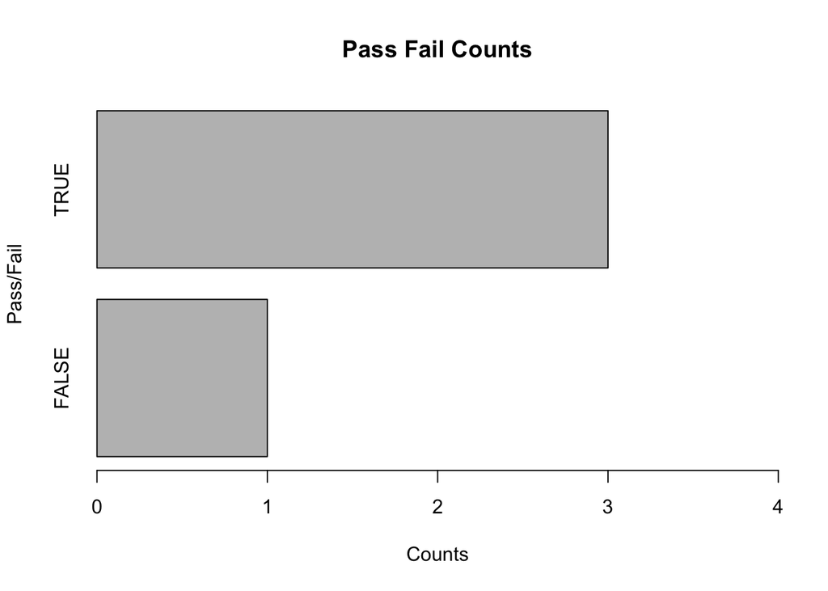

```r
barplot(table(df$Passed), horiz=TRUE, xlim=c(0,4),
        ylab='Pass/Fail', xlab='Counts', main="Pass Fail Counts")
```

Create a two column dataframe to use `hist()` to check distribution and `plot()` to see relationship between the two variables.

```r
x<-sample(1:200, 70, replace=TRUE)
y<-sample(1:200, 70, replace=TRUE)
df4<-data.frame(x,y)
names(df4)<-c('x','y')
head(df4)
```

```
##     x  y
## 1 196 37
## 2  18 39
## 3 114 94
## 4 139 19
## 5  20 45
## 6  47 83
```

```r
attach(df4)
```

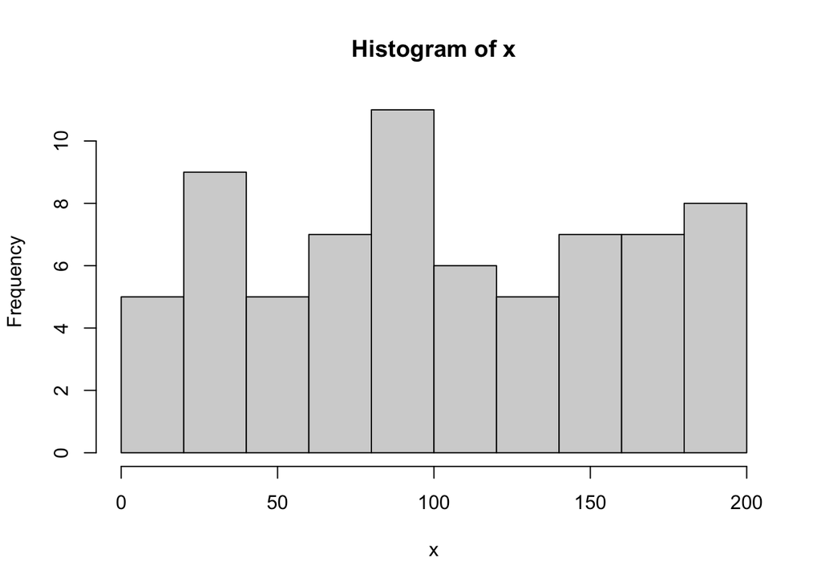

```r
hist(x)
```

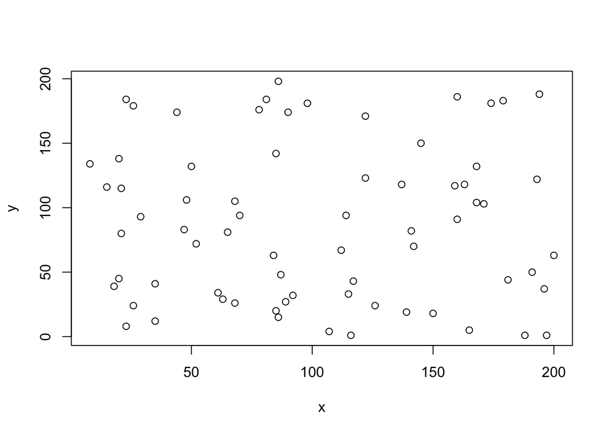

```r
plot(x,y)
```

Boxplots display quartiles. The following shows examples when there are no outliers versus when there are outliers:

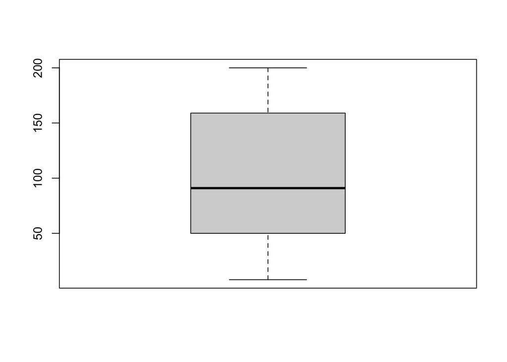

```r
boxplot(x)
```

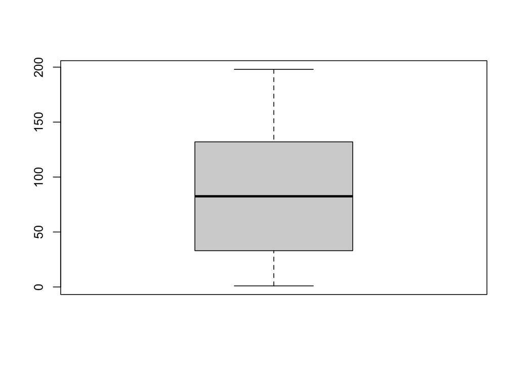

```r
boxplot(y)
```

With outliers:

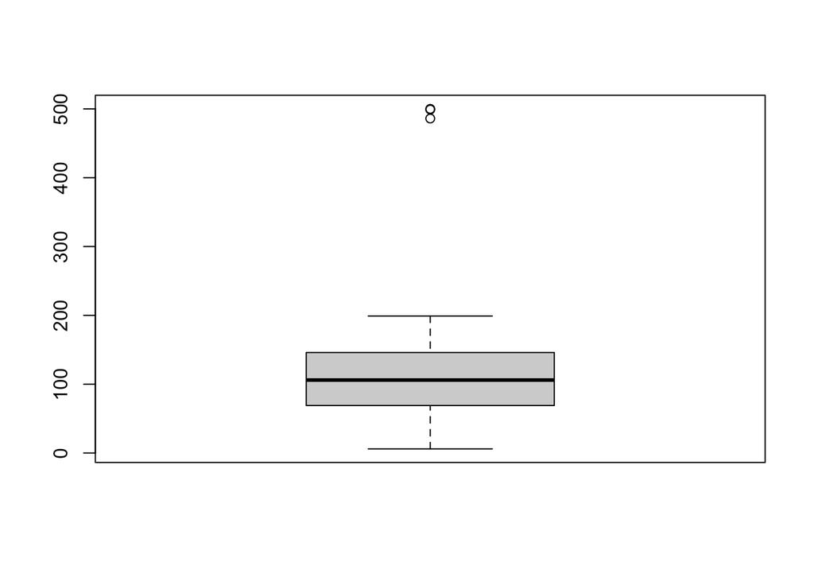

```r
y<-sample(1:200, 70, replace=TRUE)
new_y<-append(y, c(486, 499, 500))
boxplot(new_y) # displays outliers
```